# Let's try to analyze happiness

```python
happy2017 = happy2017.rename(columns={'Happiness.Rank': 'Happiness Rank','Happiness.Score': 'Happiness_score', 'Economy..GDP.per.Capita.': 'GDP','Health..Life.Expectancy.': 'Health','Trust..Government.Corruption.': 'Corruption', 'Dystopia.Residual': 'Residual','Family':'Social_support'})
happy2017.head()
```

|  | Country | Happiness Rank | Happiness_score | Whisker.high | Whisker.low | GDP | Social_support | Health | Freedom | Generosity | Corruption | Residual |
| --- | --- | --- | --- | --- | --- | --- | --- | --- | --- | --- | --- | --- |
| 0 | Norway | 1 | 7.537 | 7.594445 | 7.479556 | 1.616463 | 1.533524 | 0.796667 | 0.635423 | 0.362012 | 0.315964 | 2.277027 |
| 1 | Denmark | 2 | 7.522 | 7.581728 | 7.462272 | 1.482383 | 1.551122 | 0.792566 | 0.626007 | 0.355280 | 0.400770 | 2.313707 |
| 2 | Iceland | 3 | 7.504 | 7.622030 | 7.385970 | 1.480633 | 1.610574 | 0.833552 | 0.627163 | 0.475540 | 0.153527 | 2.322715 |
| 3 | Switzerland | 4 | 7.494 | 7.561772 | 7.426227 | 1.564980 | 1.516912 | 0.858131 | 0.620071 | 0.290549 | 0.367007 | 2.276716 |
| 4 | Finland | 5 | 7.469 | 7.527542 | 7.410458 | 1.443572 | 1.540247 | 0.809158 | 0.617951 | 0.245483 | 0.382612 | 2.430182 |

Since we merged data for 'Region' column from 2016th table, we need to check if there are any missing values.

```python
happy2[happy2['Region'].isnull()]
```

|  | Country | Happiness score | Whisker-high | Whisker-low | Residual | GDP | Social_support | Health | Freedom | Generosity | Corruption | Region |
| --- | --- | --- | --- | --- | --- | --- | --- | --- | --- | --- | --- | --- |
| 25 | Taiwan Province of China | 6.4406 | 6.524781 | 6.356419 | 2.136127 | 1.365053 | 1.435968 | 0.857375 | 0.417559 | 0.150619 | 0.077859 | NaN |
| 37 | Trinidad & Tobago | 6.1919 | 6.416219 | 5.967581 | 2.148453 | 1.222706 | 1.492152 | 0.563752 | 0.575081 | 0.171070 | 0.018647 | NaN |
| 57 | Northern Cyprus | 5.8348 | 5.954305 | 5.715294 | 1.658751 | 1.228816 | 1.211011 | 0.909132 | 0.494897 | 0.178681 | 0.153539 | NaN |
| 75 | Hong Kong SAR, China | 5.4304 | 5.523323 | 5.337477 | 0.643622 | 1.405062 | 1.289982 | 1.029650 | 0.524217 | 0.246465 | 0.291431 | NaN |
| 122 | Mozambique | 4.4166 | 4.576833 | 4.256367 | 2.249320 | 0.198004 | 0.901897 | 0.172653 | 0.530866 | 0.205628 | 0.158241 | NaN |
| 140 | Lesotho | 3.8082 | 4.044544 | 3.571856 | 1.391742 | 0.472480 | 1.214946 | 0.078981 | 0.422942 | 0.115610 | 0.111505 | NaN |
| 154 | Central African Republic | 3.0830 | 3.226582 | 2.939418 | 2.487011 | 0.023905 | 0.000000 | 0.010100 | 0.305280 | 0.218356 | 0.038344 | NaN |

Since there are just 7 lines missed, we can input them manually.

```python
happy2['Region'].unique()
```

```
array(['Western Europe', 'North America', 'Australia and New Zealand',
       'Middle East and Northern Africa', 'Latin America and Caribbean',
       'Central and Eastern Europe', nan, 'Southeastern Asia',
       'Eastern Asia', 'Sub-Saharan Africa', 'Southern Asia'], dtype=object)
```

```python
happy2.loc[154,'Region']='Sub-Saharan Africa'
happy2.loc[140,'Region']='Sub-Saharan Africa'
happy2.loc[122,'Region']='Sub-Saharan Africa'
happy2.loc[75,'Region']='Eastern Asia'
happy2.loc[57,'Region']='Middle East and Northern Africa'
happy2.loc[37,'Region']='Latin America and Caribbean'
happy2.loc[25,'Region']='Southeastern Asia'
```

```python
print("Are there any missing values for column 'Region'?: {}".format(happy2.isnull().values.any()))
```

```
Are there any missing values for column 'Region'?: False
```

One more step is to add data for population. It would be used for plotting purpouses. First, we scrap data from a website, then merge it with our data frame for 2018th year.

```python
data = pd.read_csv("gap.tsv", sep='\t')
data = data[data['year']==2007]
data = data.rename(columns={'country': 'Country'})
happy3 = pandas.merge(happy2,data.loc[:,['Country', 'pop']],how='left',on='Country')
happy3.head()
```

|  | Country | Happiness score | Whisker-high | Whisker-low | Residual | GDP | Social_support | Health | Freedom | Generosity | Corruption | Region | pop |
| --- | --- | --- | --- | --- | --- | --- | --- | --- | --- | --- | --- | --- | --- |
| 0 | Finland | 7.6321 | 7.694913 | 7.569287 | 2.595186 | 1.305095 | 1.592134 | 0.874454 | 0.680633 | 0.191638 | 0.392961 | Western Europe | 5238460.0 |
| 1 | Norway | 7.5937 | 7.657077 | 7.530323 | 2.383242 | 1.455627 | 1.582340 | 0.860763 | 0.686420 | 0.285636 | 0.339687 | Western Europe | 4627926.0 |
| 2 | Denmark | 7.5553 | 7.623292 | 7.487309 | 2.370179 | 1.351153 | 1.590453 | 0.867933 | 0.683251 | 0.284392 | 0.407917 | Western Europe | 5468120.0 |
| 3 | Iceland | 7.4952 | 7.592534 | 7.397867 | 2.425990 | 1.343301 | 1.644378 | 0.913802 | 0.676502 | 0.353233 | 0.138019 | Western Europe | 301931.0 |
| 4 | Switzerland | 7.4873 | 7.569994 | 7.404606 | 2.319529 | 1.419727 | 1.548998 | 0.927076 | 0.659779 | 0.255525 | 0.356677 | Western Europe | 7554661.0 |

Checking missing values, and there are lots of them. So, we need to find another source in the web and get missing values from it.

```python
print("Are there any missing values for column 'Population'?: {}".format(len(happy3[happy3['pop'].isnull()])))
```

```
Are there any missing values for column 'Population'?: 37
```

```python
link = "http://www.worldometers.info/world-population/population-by-country/"
f = requests.get(link)
text = f.text
soup = bs(f.text, "html.parser")
prettyHTML=soup.prettify()
t = soup.find('table',class_="table table-striped")
tt = soup.find_all("table","table table-sm table-striped")
table = pandas.read_html(prettyHTML)
df=table[0].rename(index=str, columns={"#":"rank","Country (or dependency)": "Country","Population  (2018)":"pop"})
dff= df.loc[:,['Country','pop']]
```

After we merged dataframes, we still have some rows missing. Since there are not so many, we again input them manually.

```python
A = happy3[happy3['pop'].isnull()]
AB = pandas.merge(A,dff,how='left',on='Country')
AB= AB.drop('pop_x',axis=1)
AB[AB['pop_y'].isnull()]
```

|  | Country | Happiness score | Whisker-high | Whisker-low | Residual | GDP | Social_support | Health | Freedom | Generosity | Corruption | Region | pop_y |
| --- | --- | --- | --- | --- | --- | --- | --- | --- | --- | --- | --- | --- | --- |
| 3 | Taiwan Province of China | 6.4406 | 6.524781 | 6.356419 | 2.136127 | 1.365053 | 1.435968 | 0.857375 | 0.417559 | 0.150619 | 0.077859 | Southeastern Asia | NaN |
| 5 | Trinidad & Tobago | 6.1919 | 6.416219 | 5.967581 | 2.148453 | 1.222706 | 1.492152 | 0.563752 | 0.575081 | 0.171070 | 0.018647 | Latin America and Caribbean | NaN |
| 12 | Northern Cyprus | 5.8348 | 5.954305 | 5.715294 | 1.658751 | 1.228816 | 1.211011 | 0.909132 | 0.494897 | 0.178681 | 0.153539 | Middle East and Northern Africa | NaN |
| 17 | Kosovo | 5.6621 | 5.756766 | 5.567434 | 2.254914 | 0.854804 | 1.229785 | 0.577672 | 0.448167 | 0.273847 | 0.022961 | Central and Eastern Europe | NaN |
| 21 | Hong Kong SAR, China | 5.4304 | 5.523323 | 5.337477 | 0.643622 | 1.405062 | 1.289982 | 1.029650 | 0.524217 | 0.246465 | 0.291431 | Eastern Asia | NaN |
| 24 | Macedonia | 5.1848 | 5.278505 | 5.091095 | 1.675380 | 0.959345 | 1.239322 | 0.690588 | 0.394488 | 0.173221 | 0.052461 | Central and Eastern Europe | NaN |
| 27 | Palestinian Territories | 4.7433 | 4.850597 | 4.636003 | 1.853147 | 0.642411 | 1.216771 | 0.602405 | 0.266158 | 0.085955 | 0.076457 | Middle East and Northern Africa | NaN |
| 28 | Ivory Coast | 4.6712 | 4.779968 | 4.562432 | 2.462675 | 0.540813 | 0.871533 | 0.080321 | 0.466517 | 0.146393 | 0.102956 | Sub-Saharan Africa | NaN |
| 30 | Congo (Brazzaville) | 4.5587 | 4.687742 | 4.429659 | 2.040755 | 0.681599 | 0.810759 | 0.342975 | 0.513789 | 0.091493 | 0.077301 | Sub-Saharan Africa | NaN |
| 33 | Congo (Kinshasa) | 4.2449 | 4.340780 | 4.149020 | 2.273955 | 0.069226 | 1.135616 | 0.204327 | 0.312345 | 0.197224 | 0.052252 | Sub-Saharan Africa | NaN |

```python
AB.loc[3,'pop_y'] = 23571000
AB.loc[5,'pop_y'] = 1369000
AB.loc[12,'pop_y'] = 200587
AB.loc[21,'pop_y'] = 7392000
AB.loc[17,'pop_y'] = 1831000
AB.loc[24,'pop_y'] = 2074000
AB.loc[27,'pop_y'] = 4685000
AB.loc[30,'pop_y'] = 5261000
AB.loc[33,'pop_y'] = 81339988
AB.loc[28,'pop_y'] = 24294750
AB = AB.rename(columns={'pop_y':'pop'})
```

Check for missing values:

```python
AB[AB['pop'].isnull()]
```

|  | Country | Happiness score | Whisker-high | Whisker-low | Residual | GDP | Social_support | Health | Freedom | Generosity | Corruption | Region | pop |
| --- | --- | --- | --- | --- | --- | --- | --- | --- | --- | --- | --- | --- | --- |

```python
res = pandas.merge(happy3,AB.loc[:,['Country','pop']],how='left',on='Country')
res2 = res
res2['pop_x'].update(res2['pop_y'])
res2 = res2.drop('pop_y',axis=1)
res2 = res2.rename(columns={'pop_x':'Population'})
```

The resulting data frame with addition of columns for Region and Population

```python
res2.head()
```

|  | Country | Happiness score | Whisker-high | Whisker-low | Residual | GDP | Social_support | Health | Freedom | Generosity | Corruption | Region | Population |
| --- | --- | --- | --- | --- | --- | --- | --- | --- | --- | --- | --- | --- | --- |
| 0 | Finland | 7.6321 | 7.694913 | 7.569287 | 2.595186 | 1.305095 | 1.592134 | 0.874454 | 0.680633 | 0.191638 | 0.392961 | Western Europe | 5238460.0 |
| 1 | Norway | 7.5937 | 7.657077 | 7.530323 | 2.383242 | 1.455627 | 1.582340 | 0.860763 | 0.686420 | 0.285636 | 0.339687 | Western Europe | 4627926.0 |
| 2 | Denmark | 7.5553 | 7.623292 | 7.487309 | 2.370179 | 1.351153 | 1.590453 | 0.867933 | 0.683251 | 0.284392 | 0.407917 | Western Europe | 5468120.0 |
| 3 | Iceland | 7.4952 | 7.592534 | 7.397867 | 2.425990 | 1.343301 | 1.644378 | 0.913802 | 0.676502 | 0.353233 | 0.138019 | Western Europe | 301931.0 |
| 4 | Switzerland | 7.4873 | 7.569994 | 7.404606 | 2.319529 | 1.419727 | 1.548998 | 0.927076 | 0.659779 | 0.255525 | 0.356677 | Western Europe | 7554661.0 |

To sum up, for missing data we were using three approaches: to get data from other downloaded table, to scrap data from different websources or to fill missing values manually. Nice observation of how to deal with mssing values is given here [1].

## Data analysis and visualization

Our data analysis we begin with some statistics, ehich gives us some sense about ranges for all variables and mean values.

```python
res2.describe()
```

|  | Happiness score | Whisker-high | Whisker-low | Residual | GDP | Social_support | Health | Freedom | Generosity | Corruption | Population |
| --- | --- | --- | --- | --- | --- | --- | --- | --- | --- | --- | --- |
| count | 156.000000 | 156.000000 | 156.000000 | 156.000000 | 156.000000 | 156.000000 | 156.000000 | 156.000000 | 156.000000 | 156.000000 | 1.560000e+02 |
| mean | 5.375881 | 5.478636 | 5.273126 | 1.922858 | 0.887392 | 1.216608 | 0.598043 | 0.456962 | 0.181557 | 0.112461 | 4.210332e+07 |
| std | 1.119557 | 1.107554 | 1.132541 | 0.513731 | 0.382566 | 0.300411 | 0.247919 | 0.162759 | 0.098818 | 0.096353 | 1.413909e+08 |
| min | 2.904500 | 3.074190 | 2.734810 | 0.291651 | 0.000000 | 0.000000 | 0.000000 | 0.000000 | 0.000000 | 0.000000 | 2.005870e+05 |
| 25% | 4.453450 | 4.589602 | 4.344940 | 1.654088 | 0.615981 | 1.076692 | 0.421948 | 0.358140 | 0.109587 | 0.051317 | 4.537476e+06 |
| 50% | 5.378050 | 5.477338 | 5.284564 | 1.908673 | 0.949630 | 1.261611 | 0.643736 | 0.494180 | 0.173870 | 0.081850 | 1.018950e+07 |
| 75% | 6.168450 | 6.259824 | 6.050963 | 2.269935 | 1.197638 | 1.462813 | 0.777317 | 0.579635 | 0.242243 | 0.139076 | 2.985028e+07 |
| max | 7.632100 | 7.694913 | 7.569287 | 2.960510 | 1.649054 | 1.644378 | 1.029650 | 0.724477 | 0.597568 | 0.456970 | 1.318683e+09 |

Another useful overview is correlation matrix: we can see that the highest correlation is for GDP, Health, Social support and Freedom. Interesting observation is correlation of 0.9 between GDP and Health, which is quite expectable, also correlations of 0.7 between GDP and Social support and Health and Social support. Correlations of 0.5 between Freedom and Corruption and 0.4 between Corruption and Generosity.

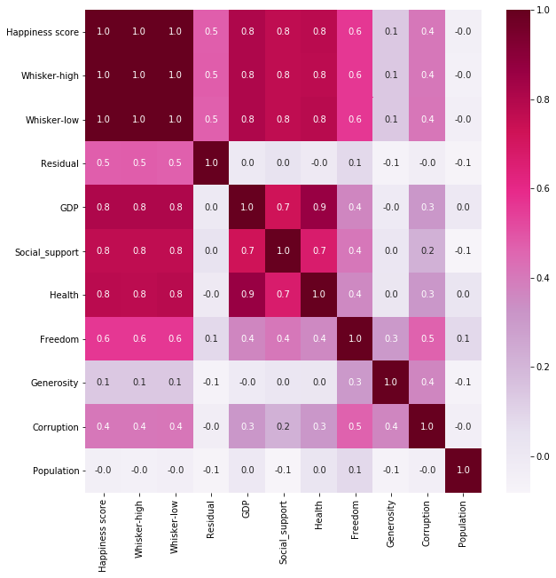

```python
f,ax = plt.subplots(figsize=(10, 10))
sns.heatmap(res2.corr(), annot=True,fmt='.1f',ax=ax,cmap='PuRd')
plt.show()
```

## Conclusion

According to the happiness institute report happiness level in United States is decreasing due to decrease in social factors, namely 4 factors except gdp and helthy life expectancy.

### References

[1] https://towardsdatascience.com/how-to-handle-missing-data-8646b18db0d4